# HW9

Natalie Brewer

2023-11-11

## Problem 9A (12.26)

```r
dogs_data <- read.table("/Users/nataliebrewer/Desktop/Stat 135/HW9/dogs.txt", sep=" ")
dogs_df <- data.frame(dogs_data)
dogs_df
```

```
##     V1   V2   V3   V4   V5   V6   V7   V8   V9  V10
## 1 0.28 0.51 1.00 0.39 0.29 0.36 0.32 0.69 0.17 0.33
## 2 0.30 0.39 0.63 0.68 0.38 0.21 0.88 0.39 0.51 0.32
## 3 1.07 1.35 0.69 0.28 1.24 1.53 0.49 0.56 1.02 0.30
```

```r
T1 <- unname(unlist(dogs_df[1,]))
T2 <- unname(unlist(dogs_df[2,]))
T3 <- unname(unlist(dogs_df[3,]))

groups <- c(rep("T1",10),rep("T2",10),rep("T3",10))
treatments <- c(T1,T2,T3)
dogs_tidy <- data.frame(groups,treatments)
head(dogs_tidy)
```

```
##   groups treatments
## 1     T1       0.28
## 2     T1       0.51
## 3     T1       1.00
## 4     T1       0.39
## 5     T1       0.29
## 6     T1       0.36
```

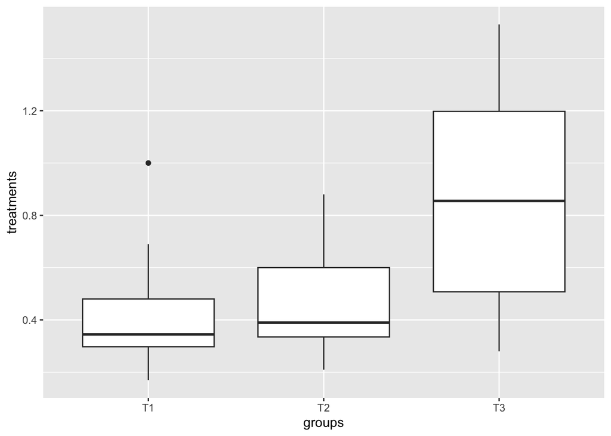

```r
dogs_tidy %>% ggplot(aes(x=groups,y=treatments)) + geom_boxplot()
```

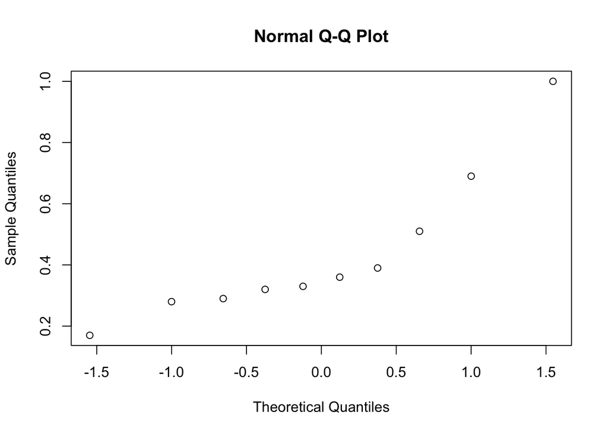

```r
qqnorm(T1)
```

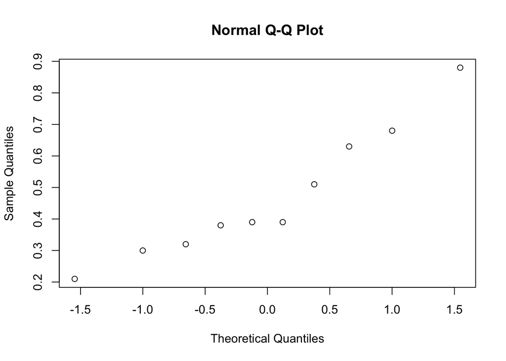

```r
qqnorm(T2)
```

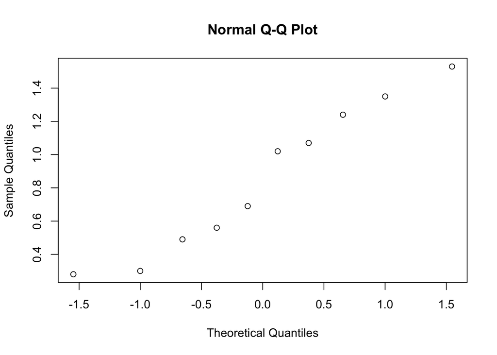

```r
qqnorm(T3)
```

1. F Test

```r
# Worked out by hand
I=3
J=10

mean_T1 <- mean(T1)
mean_T2 <- mean(T2)
mean_T3 <- mean(T3)
c(mean_T1, mean_T2, mean_T3)
```

```
## [1] 0.434 0.469 0.853
```

```r
mean_tot <- mean(treatments)
mean_tot
```

```
## [1] 0.5853333
```

```r
var_T1 <- var(T1)
var_T2 <- var(T2)
var_T3 <- var(T3)
c(var_T1, var_T2, var_T3)
```

```
## [1] 0.05967111 0.04214333 0.20093444
```

```r
SSW <- (J-1) * (var_T1 + var_T2 + var_T3)
SSW
```

```
## [1] 2.72474
```

```r
SSB <- J * ((mean_T1 - mean_tot)^2 + (mean_T2 - mean_tot)^2 + (mean_T3 - mean_tot)^2)
SSB
```

```
## [1] 1.080807
```

```r
F <- (SSB/(I-1)) / (SSW/(I*(J-1)))
F
```

```
## [1] 5.354966
```

```r
1 - pf(F,2,27)
```

```
## [1] 0.01099659
```

```r
# Check answer with R
oneway.test(treatments~groups,var.equal = TRUE)
```

```
##
##  One-way analysis of means
##
## data:  treatments and groups
## F = 5.355, num df = 2, denom df = 27, p-value = 0.011
```

2. Bonferroni Test

```r
# Just use R
pairwise.t.test(dogs_tidy$treatments,dogs_tidy$groups,p.adjust="none" )
```

```
##
##  Pairwise comparisons using t tests with pooled SD
##
## data:  dogs_tidy$treatments and dogs_tidy$groups
##
##    T1     T2
## T2 0.8073 -
## T3 0.0065 0.0117
##
## P value adjustment method: none
```

We compare these value with alpha/3 = 0.017

Based on the F-test and the Bonferroni test, there appear to be differences between the effects of the three treatments. Specifically, there is a difference between T3, which is Cyclopropane, and the other two groups.

3. Non-parametric: Kruskal Wallis Test

```r
# Just use R
kruskal.test(treatments~groups)
```

```
##
##  Kruskal-Wallis rank sum test
##
## data:  treatments by groups
## Kruskal-Wallis chi-squared = 5.6442, df = 2, p-value = 0.05948
```

## Problem 9B (12.27)

```r
AJ <- unname(unlist(read.table("/Users/nataliebrewer/Desktop/Stat 135/HW9/aj.txt", sep=" ")))
C57 <- unname(unlist(read.table("/Users/nataliebrewer/Desktop/Stat 135/HW9/c57.txt", sep=" ")))
F2 <- unname(unlist(read.table("/Users/nataliebrewer/Desktop/Stat 135/HW9/f2.txt", sep=" ")))

mice_treatments <- c(AJ, C57, F2)
mice_groups <- c(rep("AJ",length(AJ)), rep("C57",length(C57)), rep("F2",length(F2)) )

mice_tidy <- data.frame(mice_groups,mice_treatments)
head(mice_tidy)
```

```
##   mice_groups mice_treatments
## 1          AJ              37
## 2          AJ              90
## 3          AJ              39
## 4          AJ             104
## 5          AJ              43
## 6          AJ              62
```

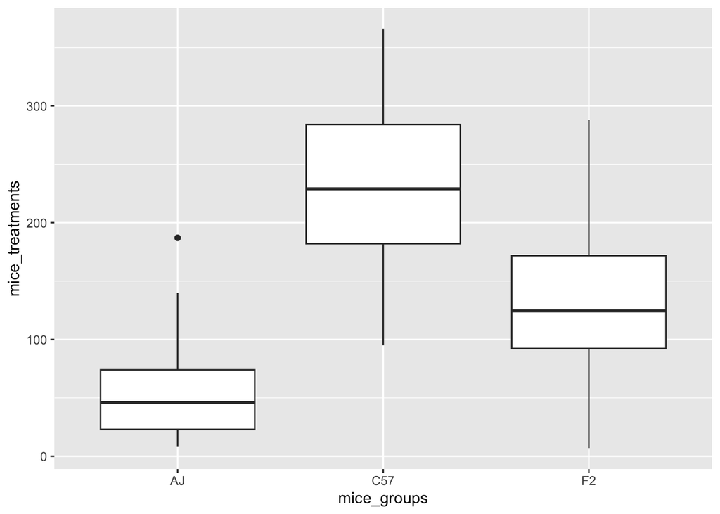

```r
# Boxplots
mice_tidy %>% ggplot(aes(x=mice_groups,y=mice_treatments)) + geom_boxplot()
```

```r
# Bonferroni test
pairwise.t.test(mice_tidy$mice_treatments,mice_tidy$mice_groups,p.adjust="bonferroni" )
```

```
##
##  Pairwise comparisons using t tests with pooled SD
##
## data:  mice_tidy$mice_treatments and mice_tidy$mice_groups
##
##     AJ      C57
## C57 < 2e-16 -
## F2  4.4e-07 3.7e-11
##
## P value adjustment method: bonferroni
```

Since we used the bonferroni adjusment for the p-values, we compare these results with the alpha level 0.05.

Because the p values are all below 0.05, we reject the null hypothesis and conclude that there are significant differences between the species of mice.

## Problem 9C (12.28)

```r
Typ1 <- c(1.7, 1.9, 6.1, 12.5, 16.5, 25.1, 30.5, 42.1, 82.5)
Typ2 <- c(13.6, 19.8, 25.2, 46.2, 46.2, 61.1)
Typ3 <- c(13.4, 20.9, 25.1, 29.7, 46.9)

watch_results <- c(Typ1, Typ2, Typ3)
watch_types <- c(rep("Typ1",length(Typ1)), rep("Typ2",length(Typ2)), rep("Typ3",length(Typ3)) )

watch_tidy <- data.frame(watch_types,watch_results)
head(watch_tidy)
```

```
##   watch_types watch_results
## 1        Typ1           1.7
## 2        Typ1           1.9
## 3        Typ1           6.1
## 4        Typ1          12.5
## 5        Typ1          16.5
## 6        Typ1          25.1
```

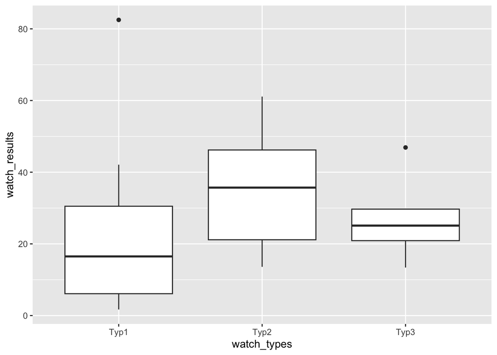

```r
# Boxplots
watch_tidy %>% ggplot(aes(x=watch_types,y=watch_results)) + geom_boxplot()
```

```r
# F test
oneway.test(watch_results~watch_types,var.equal = TRUE)
```

```
##
##  One-way analysis of means
##
## data:  watch_results and watch_types
## F = 0.4974, num df = 2, denom df = 17, p-value = 0.6167
```

```r
# Bonferroni test
pairwise.t.test(watch_tidy$watch_results,watch_tidy$watch_types,p.adjust="bonferroni")
```

```
##
##  Pairwise comparisons using t tests with pooled SD
##
## data:  watch_tidy$watch_results and watch_tidy$watch_types
##
##      Typ1 Typ2
## Typ2 1    -
## Typ3 1    1
##
## P value adjustment method: bonferroni
```

```r
# Kruskal Wallis test
kruskal.test(watch_results~watch_types)
```

```
##
##  Kruskal-Wallis rank sum test
##
## data:  watch_results by watch_types
## Kruskal-Wallis chi-squared = 2.1547, df = 2, p-value = 0.3405
```

Based on the results of both the parametric and nonparametric tests, we fail to reject the null hypothesis and conclude that the watch types are not significantly different.